# Reliability of point daily and monthly data

```r
library(BOMcatchr)
```

This example demonstrates the reliability of the package by comparing extracted data against observations from six rainfall and temperate gauges. The building and extraction of data at user-defined time-step is first demonstrated.

## Make netCDF file

```r
dataFrom = as.Date("2010-01-01","%Y-%m-%d")
dataTo = as.Date("2010-12-31","%Y-%m-%d")
```

To start to create the grids, the file name for the netCDF grids needs to be defined. Here we’ll just use a temporary file. You should change this to a non-temporary file name and folder.

```r
ncdfFilename = tempfile(fileext='.nc')
```

```r
fnames = grid_build(ncdfFilename = ncdfFilename,
                         updateFrom = dataFrom,
                         updateTo = dataTo,
                         vars = c('tmax', 'precip', 'precip.monthly'))
```

```
#> ... Testing downloading of each variable.
#>     Testing tmax grid data.
#>     Testing precip grid data.
#>     Testing precip.monthly grid data.
#> ... Checking updateFrom and updateTo dates.
#> ... NetCDF file will be updated as follows:
#>        - New variables to add: tmax  precip  precip.monthly
#>        - Existing variables to modify: (none)
#>        - Data will be updated from  2010-01-01  to  2010-12-31
#> ... Downloading data for each variable and importing to netcdf file:
#> Data construction FINISHED.
#> Summary of time points successfully imported (and errors).
#>                Imported Errors
#> tmax                365      0
#> precip              365      0
#> precip.monthly       12      0
#> Total run time (DD:HH:MM:SS): 00:00:04:46
```

## Set the points for data extraction and map

```r
data("weather_gauge_loc")

coords = terra::vect(weather_gauge_loc,
                     crs = 'EPSG:4283',
                     geom = c("longitude", "latitude")
                     )

n_sites = nrow(coords)
```

Now let’s download a polygon of Australia and map the extraction location on top of it (as red circles).

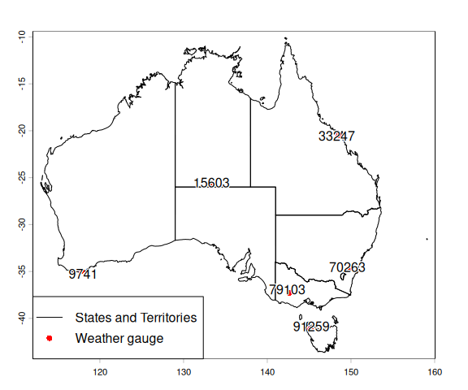

```r
st = extract_locations('state',id=NA)

terra::plot(st)
terra::plot(coords, , col='red',add=T)
terra::text(coords, labels=coords$site_ID, halo=TRUE, jitter = 10)

terra::add_legend('bottomleft',
                  legend = c('States and Territories', 'Weather gauge'),
                  col=c('black','red'),
                  pch = c(NA,16),
                  lty=c(1,NA)
                  )
```

To evidence the weather gauges being close to the centre of each grid cell, the maps below show the boundary and centre of the grid cells neighbouring each gauge. The red circle show the location of the gauge. The black cross the centre of the grid cell, which is the point at which the grid cell estimate corresponds to (i.e. here not the lower-left). The grey squares are the boundaries of each grid cell.

The maps show that the gauges are less than 0.01 degrees from the centre of a grid cell. This equates to approximately less than 1 km and is unlikely to introduce major error in the latter comparisons extracted data at the grid cell.

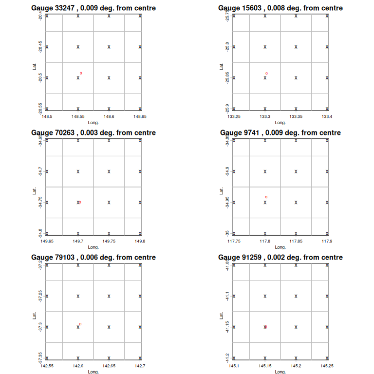

```r
par(mfrow = c(n_sites/2, 2),
    pty = "s",
    cex = 0.75)

# Extract rainfall terra:rast grid at one time point
r  = extract_layer(ncdfFilename = ncdfFilename,
                   extract.date = dataFrom,
                   var = c('precip'))

# Get coordinate of grid cell centre.
v = terra::xyFromCell(r, 1:(terra::ncol(r)*terra::nrow(r)) )
v = terra::vect(v,  crs = 'EPSG:4283')

# Map around each gauge
for (i in 1:n_sites){
  coord_box = c(weather_gauge_loc[i, 'longitude'] - 0.1,
                weather_gauge_loc[i, 'longitude'] + 0.1,
                weather_gauge_loc[i, 'latitude'] - 0.1,
                weather_gauge_loc[i, 'latitude'] + 0.1
                )
  coord_ext = terra::ext(coord_box)
  crd = terra::vect(weather_gauge_loc[i,],
                    crs = 'EPSG:4283',
                    geom = c('longitude', 'latitude')
                   )
  v_crp = terra::crop(v, coord_ext)
  r_crp = terra::crop(r, coord_ext)

  r_crp <- terra::as.polygons(r_crp, aggregate=FALSE)

  dist = sqrt( (weather_gauge_loc[i, 'longitude'] - terra::crds(v_crp)[, 1])^2 +
               (weather_gauge_loc[i, 'latitude'] - terra::crds(v_crp)[, 2])^2)
  dist = min(dist)

  terra::plot(v_crp,
              xlab = 'Long.',
              ylab = 'Lat.',
              main = paste('Gauge', weather_gauge_loc[i,'site_ID'], ',',round(dist,3),'deg. from centre'),
              col='black',
              pch='x',
              asp=1)
  terra::lines(r_crp, col='grey')
  terra::points(crd, pch='o', col='red')
}
```

Note the netCDF file must be in the working directory or the full file path must be given.

```r
extracted.data = extract_data(ncdfFilename = ncdfFilename,
                                        extractFrom = dataFrom,
                                        extractTo = dataTo,
                                        locations = coords,
                                        vars = c('tmax', 'precip'),
                                        ET.function='')
```

```
#> Extraction data summary:
#>     NetCDF climate data exists from 2010-01-01 to 2010-12-31
#>     Data will be extracted from  2010-01-01  to  2010-12-31  at  6  locations
#> Setting up data extraction:
#> ... Testing aggregation functions:
#>    ... Testing temporal aggregation
#> ... Building catchment weights for each grid.
#> Starting data extraction across all variable and locations:
#> ... Infilling data gaps by interpolating over time, then back-filling.
#>    ... Linearly interpolating gaps.
#>    ... Backfilling dates prior to the start of observations (if required).
#>     Summary of NAs initially, and after each step.
#>        pre.filled post.time.interpolated post.backfilling
#> tmax            0                      0                0
#> precip          0                      0                0
#> ... Calculating area weighted results at required time-step.
#> Data extraction FINISHED.
#> Total run time (DD:HH:MM:SS): 00:00:00:34
```

## Plot the extracted data over time

Now let’s plot time series of the extracted daily precipitation and maximum temperature.

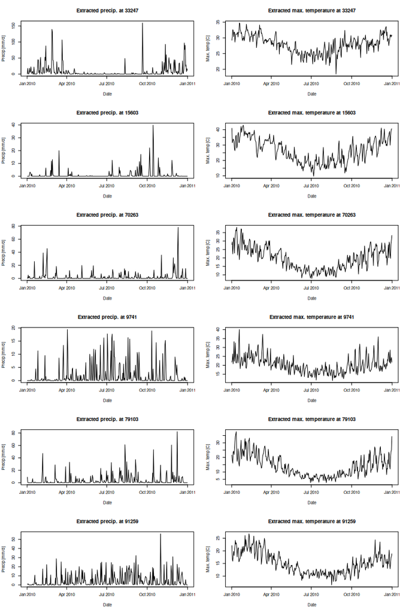

```r
par(mfrow = c(n_sites, 2), cex = 0.5)
for (i in 1:n_sites){
  filt = extracted.data$Location.ID == coords$site_ID[i]

  dates = ISOdate(extracted.data$year[filt],
                  extracted.data$month[filt],
                  extracted.data$day[filt])

  data2plot = extracted.data$precip[filt]
  plot(dates, data2plot,
       main = paste('Extracted precip. at',coords$site_ID[i]),
       ylab = 'Precip [mm/d]',
       xlab = 'Date',
       type = 'l')

  data2plot = extracted.data$tmax[filt]
  plot(dates, data2plot,
       main = paste('Extracted max. temperature at',coords$site_ID[i]),
       ylab = 'Max. temp [C]',
       xlab = 'Date',
       type = 'l')
}
```

## Check extracted data against gauge data

To assess the reliability of the extracted rain gauge data, let’s use the following observed precipitation for 2010 (from gauge_63005), sourced from the Australian Bureau of Meteorology.

```r
data("weather_gauge_obs")
```

Now let’s compare the extracted data against the gauge data.

The left column shows the gauge and extracted daily precipitation. Similarly, the middle column shows that for the cumulative daily precipitation and the right column shows that for the daily maximum temperature. All plots include the 1:1 line.

Overall, the results show that the gridded rainfall has a RMSE of 1 to 5mm mm/day and an absolute bias of less than 0.5 mm/day. In comparison, the cross-validation of the gauge interpolations techniques used by the BoM (see Table 3 in Jones et al. 2009 at \url(https://doi.org/10.1071/ES09032)) show an RMSE for 2001-2007 of 3.1 mm/day. Additionally, Fig 8B in Jones et al. 2009 shows a strong north-south gradient in the daily rainfall RMSE. Similarly, the most northern gauge used here (33247) show a larger RMSE of (5 mm/day) than the southern gauges. Overall, the rainfall errors reported below are very comparable to that reported by Jones et al. (2009). Hence the errors shown below are very unlikely to arise from the package data handling.

On the maximum temperature, it generally has a low RMSE of 0.6 to 2 degree Celsius and an absolute bias of 0.1 to 0.4 C. The only exception is gauge 79103 with an RMSE of 3 C and bias of -2 C, but this gauge it at an elevation of 1150 m and on a summit. In comparison, Table 2B in Jones et al. 2009 reports an RMSE of 1.2 C and a zero bias. Overall, the error in the maximum temperature is generally low and below that of Jones et al. (2009). Again the errors shown below are very unlikely to arise from the package data handling.

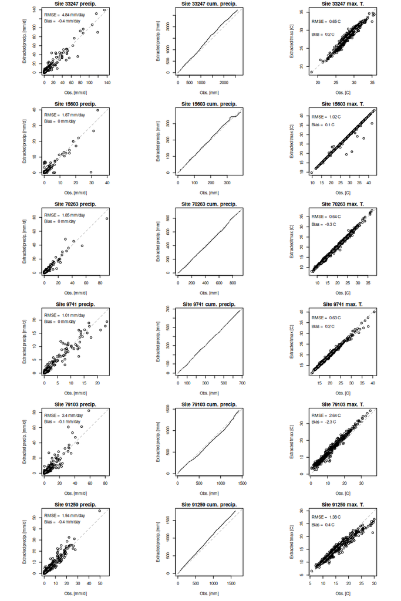

```r
par(mfrow = c(n_sites, 3),
    mar = c(5, 5, 1.5, 1.5),
    pty = "s",
    cex = 0.5)

for (i in 1:n_sites){

  filt_obs = weather_gauge_obs$site_ID == coords$site_ID[i]
  xdata = weather_gauge_obs[ which(filt_obs), ]$precip_mmday

  filt_grd = extracted.data$Location.ID == coords$site_ID[i]
  ydata = extracted.data[filt_grd, ]$precip

  filt_obsErr = !(is.na(xdata) | xdata == -999)
  xdata = xdata[ filt_obsErr ]
  ydata = ydata[ filt_obsErr ]

  shared_limits <- range(c(xdata, ydata))
  plot(xdata,
       ydata,
       xlim = shared_limits,
       ylim = shared_limits,
       asp = 1,
       main = paste('Site', coords$site_ID[i], 'precip.'),
       xlab = 'Obs. [mm/d]',
       ylab = 'Extracted precip. [mm/d]')
  abline(0,1, col='grey', lty=2)
  rmse = round(sqrt(mean((xdata - ydata)^2)), 2)
  bias = round(mean(xdata - ydata), 1)
  text(x=shared_limits[1], y=shared_limits[2]*0.9, adj = c(0,0),
       labels = paste('RMSE = ', rmse, 'mm/day'))
  text(x=shared_limits[1], y=shared_limits[2]*0.8, adj = c(0,0),
       labels = paste('Bias = ', bias, 'mm/day'))

  xdata = cumsum(xdata)
  ydata = cumsum(ydata)
  shared_limits <- range(c(xdata, ydata))
  plot(xdata,
       ydata,
       xlim = shared_limits,
       ylim = shared_limits,
       asp = 1,
       main = paste('Site', coords$site_ID[i], 'cum. precip.'),
       xlab = 'Obs. [mm]',
       ylab = 'Extracted precip. [mm]',
       type = 'l')
  abline(0,1, col='grey', lty=2)

  xdata = weather_gauge_obs[ which(filt_obs), ]$tmax_C
  ydata = extracted.data[ filt_grd, ]$tmax

  filt_obsErr = !(is.na(xdata) | xdata == -999)
  xdata = xdata[ filt_obsErr ]
  ydata = ydata[ filt_obsErr ]
  shared_limits <- range(c(xdata, ydata))
  plot(xdata,
       ydata,
       xlim = shared_limits,
       ylim = shared_limits,
       asp = 1,
       main =paste('Site', coords$site_ID[i], 'max. T.'),
       xlab ='Obs. [C]',
       ylab ='Extracted tmax [C]')
  abline(0,1, col='grey', lty=2)
  rmse = round(sqrt(mean((xdata - ydata)^2)), 2)
  bias = round(mean(xdata - ydata), 1)
  text(x=shared_limits[1], y=shared_limits[2]*0.9, adj = c(0,0),
       labels = paste('RMSE = ', rmse, 'C'))
  text(x=shared_limits[1], y=shared_limits[2]*0.8, adj = c(0,0),
       labels = paste('Bias = ', bias, 'C'))
}
```

## Check extracted data against monthly precipitation gauge data

Now let’s compare the gauge data at a monthly time step with the extracted monthly data and aggregated daily data to a monthly time scale.

First, let’s extract the daily data at a monthly scale

```r
extracted.daily2monthly = extract_data(ncdfFilename = ncdfFilename,
                                        extractFrom = dataFrom,
                                        extractTo = dataTo,
                                        locations = coords,
                                        vars = c('precip'),
                                        temporal.timestep = 'monthly',
                                        temporal.fn.inner = 'sum',
                                        ET.function='')
```

```
#> Extraction data summary:
#>     NetCDF climate data exists from 2010-01-01 to 2010-12-31
#>     Data will be extracted from  2010-01-01  to  2010-12-31  at  6  locations
#> Setting up data extraction:
#> ... Testing aggregation functions:
#>    ... Testing temporal aggregation
#> ... Building catchment weights for each grid.
#> Starting data extraction across all variable and locations:
#> ... Infilling data gaps by interpolating over time, then back-filling.
#>    ... Linearly interpolating gaps.
#>    ... Backfilling dates prior to the start of observations (if required).
#>     Summary of NAs initially, and after each step.
#>        pre.filled post.time.interpolated post.backfilling
#> precip          0                      0                0
#> ... Calculating area weighted results at required time-step.
#> Data extraction FINISHED.
#> Total run time (DD:HH:MM:SS): 00:00:00:17
```

Next let’s extract the monthly data product.

```r
extracted.monthly = extract_data(ncdfFilename = ncdfFilename,
                                        extractFrom = dataFrom,
                                        extractTo = dataTo,
                                        locations = coords,
                                        vars = c('precip.monthly'),
                                        temporal.timestep = 'monthly',
                                        ET.function='')
```

```
#> Extraction data summary:
#>     NetCDF climate data exists from 2010-01-01 to 2010-12-31
#>     Data will be extracted from  2010-01-01  to  2010-12-31  at  6  locations
#> Setting up data extraction:
#> ... Testing aggregation functions:
#>    ... Testing temporal aggregation
#> ... Building catchment weights for each grid.
#> Starting data extraction across all variable and locations:
#> ... Infilling data gaps by interpolating over time, then back-filling.
#>    ... Linearly interpolating gaps.
#>    ... Backfilling dates prior to the start of observations (if required).
#>     Summary of NAs initially, and after each step.
#>                pre.filled post.time.interpolated post.backfilling
#> precip.monthly          0                      0                0
#> ... Calculating area weighted results at required time-step.
#> Data extraction FINISHED.
#> Total run time (DD:HH:MM:SS): 00:00:00:00
```

Now we can compare the extracted estimates of monthly precipitation with the gauge monthly precipitation.

The left column shows the monthly gauged precipitation vs the extracted daily precipitation summed to monthly. It shows that the daily gridded data summed to monthly has a RMSE of 4 to 84 and an absolute bias of 1 to 45 mm/month. In comparison, the cross-validation of the gauge interpolations techniques used by the BoM (see Table 3A in Jones et al. 2009 at \url(https://doi.org/10.1071/ES09032)) show an RMSE for 2001-2007 of 21 mm/month and a bias of 0.5 mm/month. Additionally, Fig 8A in Jones et al. 2009 shows a very strong north-south gradient in the monthly rainfall RMSE that range from below 10 mm/month in the south to over 50 mm/month in the north. Similarly, the northern gauge reported here (33247) show a higher RMSE of 84 mm/month while the southern gauges (70263, 9741, 79103 and 91259) show a much lower RMSE of 3.5 to 24 mm/month. Again, the gauge 79103 at an elevation of 1150 m and on a summit has a higher RMSE of 24 mm/month. Overall, the rainfall errors reported below are very comparable to that reported by Jones et al. (2009). Hence the errors shown below are very unlikely to arise from the package data handling and aggregation to a monthly time-step.

The centre column shows the monthly gauged precipitation vs the extracted monthly precipitation (i.e. the gridded monthly precipitation). It shows a very comparable RMSE and bias to the daily gridded precipitation in the left column.

The right column shows the extracted monthly precipitation against the extracted daily precipitation summed to monthly. It does not show an obvious difference between the two estimates of monthly precipitation, though the most southern gauges the summed daily precipitation is slighly higher then the monthly gridded precipitation (as least for 2010).

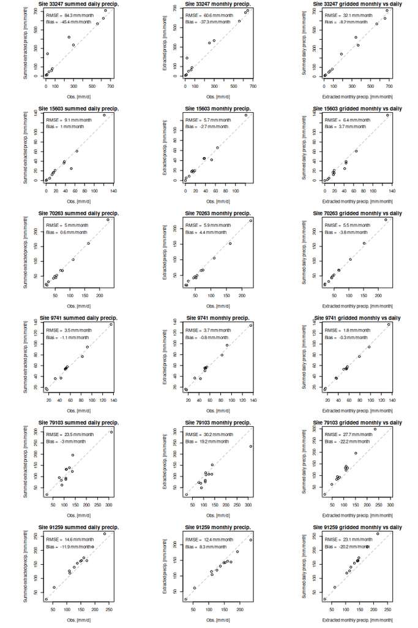

```r
par(mfrow = c(n_sites, 3),
    mar = c(5, 5, 1.5, 1.5),
    pty = "s",
    cex = 0.5)

for (i in 1:n_sites){
  xdata = weather_gauge_obs[ weather_gauge_obs$site_ID == as.numeric(coords$site_ID[i]), ]
  filt_obsErr = !(is.na(xdata$precip_mmday) | xdata$precip_mmday == -999)
  xdata = xdata[filt_obsErr, ]

  xdata = xts::as.xts(xdata[, 'precip_mmday'], order.by=xdata[, 'date'])
  xdata = xts::apply.monthly(xdata, apply, 2, 'sum')
  xdata = as.numeric(xdata[])

  filt = extracted.daily2monthly$Location.ID == coords$site_ID[i]
  ydata = extracted.daily2monthly[ filt, 'precip']

  shared_limits <- range(c(xdata, ydata))
  plot(xdata,
       ydata,
       xlim = shared_limits,
       ylim = shared_limits,
       asp = 1,
       main = paste('Site', coords$site_ID[i], 'summed daily precip.'),
       xlab ='Obs. [mm/d]',
       ylab ='Summed extracted precip. [mm/month]')
  abline(0,1, col='grey', lty=2)
  rmse = round(sqrt(mean((xdata - ydata)^2)), 1)
  bias = round(mean(xdata - ydata), 1)
  text(x=shared_limits[1], y=shared_limits[2]*0.9, adj = c(0,0),
       labels = paste('RMSE = ', rmse, 'mm/month'))
  text(x=shared_limits[1], y=shared_limits[2]*0.8, adj = c(0,0),
       labels = paste('Bias = ', bias, 'mm/month'))
  ydata = extracted.monthly$precip.monthly[filt]
  shared_limits <- range(c(xdata, ydata))
  plot(xdata,
       ydata,
       xlim = shared_limits,
       ylim = shared_limits,
       asp = 1,
       main = paste('Site', coords$site_ID[i], 'monthly precip.'),
       xlab ='Obs. [mm/d]',
       ylab ='Extracted precip. [mm/month]')
  abline(0,1, col='grey', lty=2)
  rmse = round(sqrt(mean((xdata - ydata)^2)), 1)
  bias = round(mean(xdata - ydata), 1)
  text(x=shared_limits[1], y=shared_limits[2]*0.9, adj = c(0,0),
       labels = paste('RMSE = ', rmse, 'mm/month'))
  text(x=shared_limits[1], y=shared_limits[2]*0.8, adj = c(0,0),
       labels = paste('Bias = ', bias, 'mm/month'))

  xdata = extracted.monthly$precip.monthly[filt]
  ydata = extracted.daily2monthly[ filt, 'precip']
  shared_limits <- range(c(xdata, ydata))
  plot(xdata,
       ydata,
       xlim = shared_limits,
       ylim = shared_limits,
       asp = 1,
       main = paste('Site', coords$site_ID[i], 'gridded monthly vs daily'),
       xlab ='Extracted monthly precip. [mm/month]',
       ylab ='Summed daily precip. [mm/month]')
  abline(0,1, col='grey', lty=2)
  rmse = round(sqrt(mean((xdata - ydata)^2)), 1)
  bias = round(mean(xdata - ydata), 1)
  text(x=shared_limits[1], y=shared_limits[2]*0.9, adj = c(0,0),
       labels = paste('RMSE = ', rmse, 'mm/month'))
  text(x=shared_limits[1], y=shared_limits[2]*0.8, adj = c(0,0),
       labels = paste('Bias = ', bias, 'mm/month'))
}
```